# Advanced Tree Models – Random Forests

In this lab, we will cover some state-of-the-art techniques in the framework of tree models. We use the same datasets as in previous lab, Boston Housing data and (Taiwan) Credit Card default data (subsample n=12,000 rows).

```r
# load Boston data
library(MASS)
data(Boston)
index <- sample(nrow(Boston),nrow(Boston)*0.9)
boston_train <- Boston[index,]
boston_test <- Boston[-index,]
```

# 1 Random Forests

Random forest is an extension of Bagging, but it makes significant improvement in terms of prediction. The idea of random forests is to randomly select $m$ out of $p$ predictors as candidate variables for each split in each tree. Commonly, $m=\sqrt{p}$. The reason of doing this is that it can *decorrelates* the trees such that it reduces variance when we aggregate the trees. You may refer [Wikipedia](https://en.wikipedia.org/wiki/Random_forest) and the [tutorial](https://www.stat.berkeley.edu/~breiman/RandomForests/cc_home.htm) on the author’s website. Note: The current `randomForest` package do not handle asymmetric loss.

## 1.1 Random Forest for Regression

We start with Boston Housing data.

```r
library(randomForest)
boston_rf<- randomForest(medv~., data = boston_train, importance=TRUE)
boston_rf
```

```
##
## Call:
##  randomForest(formula = medv ~ ., data = boston_train, importance = TRUE)
##                Type of random forest: regression
##                      Number of trees: 500
## No. of variables tried at each split: 4
##
##           Mean of squared residuals: 11.08914
##                     % Var explained: 87.28
```

```r
mod_rf <- randomForest(medv~., data=boston_train,
                       importance=TRUE, ntree=500)
```

By default, $m=p/3$ for regression tree, and $m=\sqrt{p}$ for classification problem. You can change it by specifying `mtry=`. You can also specify number of trees by `ntree=`. The default is 500. The argument `importance=TRUE` allows us to see the variable imporatance.

```r
boston_rf$importance
```

```
##            %IncMSE IncNodePurity
## crim     9.1487799     2282.5991
## zn       0.8784958      338.9850
## indus    7.3366002     2502.4979
## chas     0.7791308      198.7500
## nox     10.1666715     2607.2581
## rm      35.8358241    11632.6061
## age      3.6789488     1038.3863
## dis      7.0731076     2321.3044
## rad      1.2729974      300.7295
## tax      4.1715283     1108.6569
## ptratio  6.7028875     2289.0292
## black    1.5354005      761.6598
## lstat   59.1295517    11446.3160
```

```r
mod_rf$importance
```

```
##            %IncMSE IncNodePurity
## crim     7.5030519     2229.3809
## zn       0.9438600      332.0033
## indus    7.3103953     2668.3486
## chas     0.6520222      197.6725
## nox      9.9196462     2509.3762
## rm      33.0350501    10578.9897
## age      4.2951549     1072.4121
## dis      6.8003864     2312.4284
## rad      1.2211574      291.7995
## tax      5.0690632     1440.2261
## ptratio  6.6045147     2380.3511
## black    1.6871032      765.9390
## lstat   60.1514962    11962.8699
```

The MSR is MSE of *out-of-bag* prediction (recall the OOB in bagging). The fitted randomForest actually saves all OOB errors for each `ntree` value from 1 to 500. We can make a plot to see how the OOB error changes with different `ntree`.

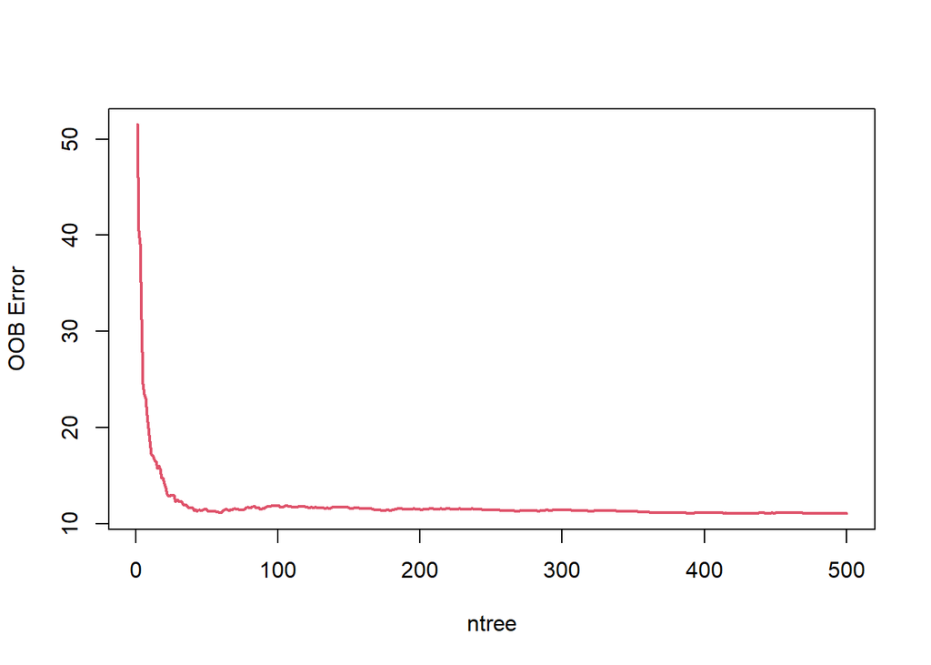

```r
plot(boston_rf$mse, type='l', col=2, lwd=2, xlab = "ntree", ylab = "OOB Error")
```

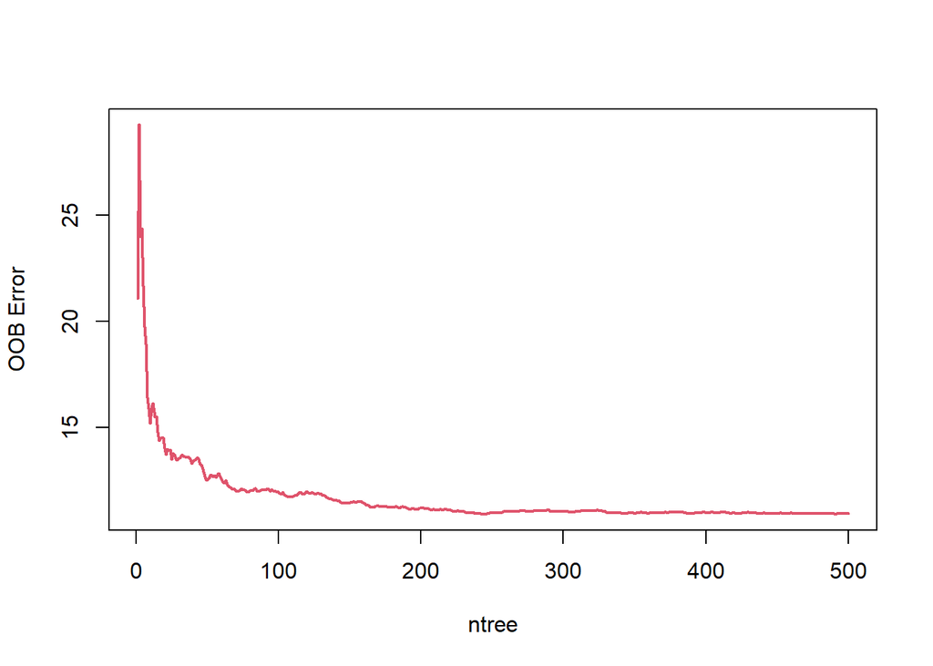

```r
plot(mod_rf$mse, type='l', col=2, lwd=2, xlab = "ntree", ylab = "OOB Error")
```

Prediction on the testing sample.

```r
boston_rf_pred<- predict(boston_rf, boston_test)
mean((boston_test$medv-boston_rf_pred)^2)
```

```
## [1] 3.511621
```

As we mentioned before, the number of candidate predictors in each split is $m=p/3\approx 4$. We can also specify $m$ with argument `mtry`. Now let’s see how the OOB error and testing error changes with `mtry`.

```r
oob_err <- rep(0, 13)
test.err <- rep(0, 13)
for(i in 1:13){
  fit<- randomForest(medv~., data = boston_train, mtry=i)
  oob_err[i]<- fit$mse[500]
  test.err[i]<- mean((boston_test$medv-predict(fit, boston_test))^2)
  cat(i, " ")
}
```

```
## 1  2  3  4  5  6  7  8  9  10  11  12  13
```

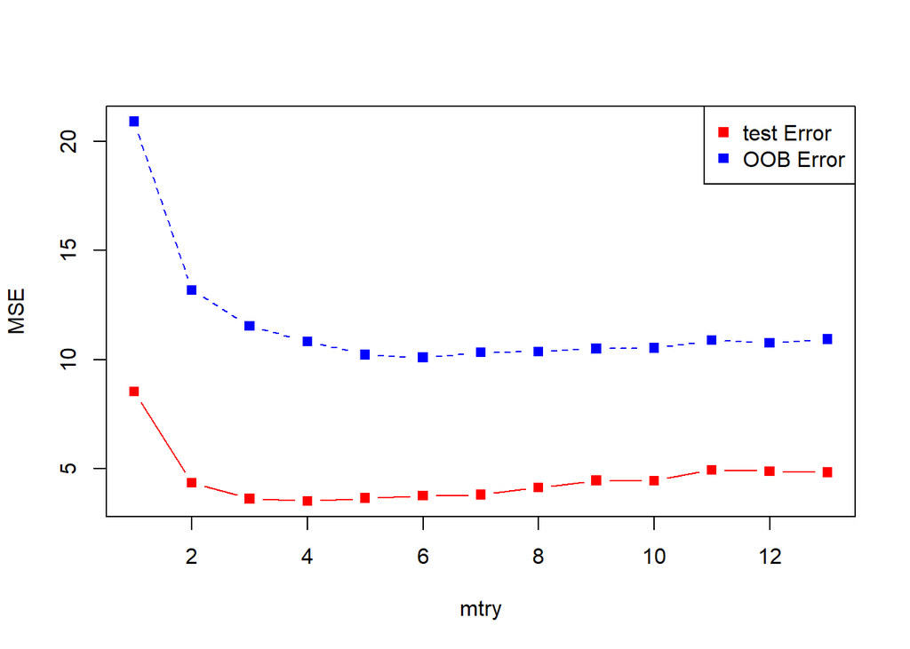

```r
matplot(cbind(test.err, oob_err), pch=15, col = c("red", "blue"), type = "b", ylab = "MSE", xlab = "mtry")
legend("topright", legend = c("test Error", "OOB Error"), pch = 15, col = c("red", "blue"))
```

> Exercise:

> Create a plot displaying the test error across `ntree=`1, …, 500, and `mtry=` 1, …, 13. (You can draw 13 lines in different color representing each $m$).

## 1.2 Random Forest for Classification

We apply the random forest model to the credit card dataset:

```r
# load credit card data
credit_data <- read.csv(file = "https://yanyudm.github.io/Data-Mining-R/lecture/data/credit_default.csv", header=T)
# convert categorical variables
credit_data$SEX<- as.factor(credit_data$SEX)
credit_data$EDUCATION<- as.factor(credit_data$EDUCATION)
credit_data$MARRIAGE<- as.factor(credit_data$MARRIAGE)
# random splitting
index <- sample(nrow(credit_data),nrow(credit_data)*0.9)
credit_train = credit_data[index,]
credit_test = credit_data[-index,]

credit_rf <- randomForest(as.factor(default.payment.next.month)~.,
                          data = credit_train,
                          importance=TRUE, ntree=500)
credit_rf
```

```
##
## Call:
##  randomForest(formula = as.factor(default.payment.next.month) ~      ., data = credit_train, importance = TRUE, ntree = 500)
##                Type of random forest: classification
##                      Number of trees: 500
## No. of variables tried at each split: 4
##
##         OOB estimate of  error rate: 18.13%
## Confusion matrix:
##      0   1 class.error
## 0 7968 471   0.0558123
## 1 1487 874   0.6298179
```

We can again easily plot the error rate vs. ntree. However, as far as I know, `randomForest` does not support asymmetric loss either. So it always uses the overall misclassification rate as the error.

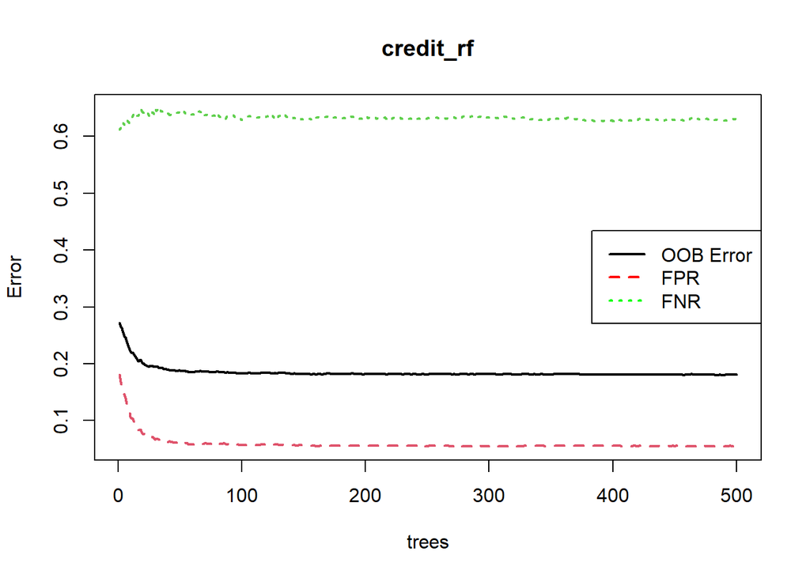

```r
plot(credit_rf, lwd=rep(2, 3))
legend("right", legend = c("OOB Error", "FPR", "FNR"), lwd=rep(2, 3), lty = c(1,2,3), col = c("black", "red", "green"))
```

ROC curve and AUC can be obtained based on the probability prediction.

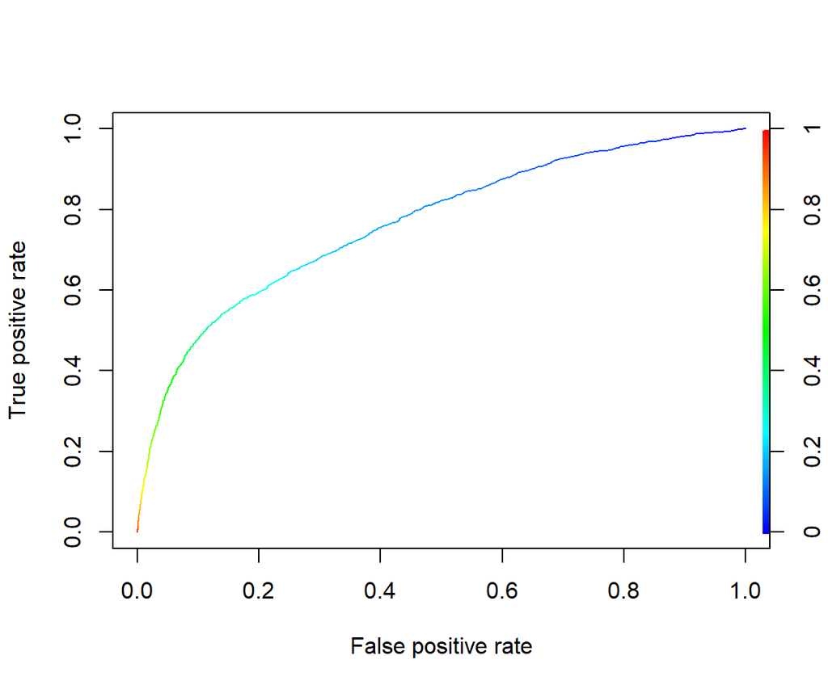

```r
credit_rf_pred <- predict(credit_rf, type = "prob")[,2]
library(ROCR)
pred <- prediction(credit_rf_pred, credit_train$default.payment.next.month)
perf <- performance(pred, "tpr", "fpr")
plot(perf, colorize=TRUE)
```

```r
#Get the AUC
unlist(slot(performance(pred, "auc"), "y.values"))
```

```
## [1] 0.7662187
```

Create the confusion matrix based on the cutoff probability from asymmetric cost (pcut=1/6).

```r
## out-of-sample
pcut <- 1/6
credit_rf_pred_test <- predict(credit_rf, newdata=credit_test, type = "prob")[,2]
credit_rf_class_test <- (credit_rf_pred_test>pcut)*1
table(credit_test$default.payment.next.month, credit_rf_class_test, dnn = c("True", "Pred"))
```

```
##     Pred
## True   0   1
##    0 518 411
##    1  62 209
```